# Temporal analysis

Nicolas Roelandt

2022-01-06

```r
con <- DBI::dbConnect(
drv,
dbname ="noisecapture",
host = "lassopg.ifsttar.fr", #server IP or hostname
port = 5432, #Port on which we ran the proxy
user="noisecapture",
password=Sys.getenv('noisecapture_password') # password stored in .Renviron. Use this to edit it : usethis::edit_r_environ()
)
```

# Data cleaning

The data stored in the database is not useable as is. Most of the data is not taggued, the accuraccy of the GPS position can vary, the track is too long. So the data needs to be filtered.

This has be done within the database using views. Please see the 03_create_views.sql script for more details.

In summary, it removes test and indoor records, filter tracks that have a duration between 5 to 900 seconds. It also remove the tracks where the GPS accuracy was below a 20 meter threshold and that are larger than a 25 square meter area.

This study is focused on France so there is a spatial filtering on its boundaries.

The final data is stored in a view called `france_tracks` that can be called at will.

## Retrieve data

### Track information

```r
query <- "SELECT  pk_track, record_utc, time_length, pleasantness, noise_level, track_uuid, geog
FROM france_tracks;"

track_info <- sf::st_read(con,query = query)
track_info %>% head()
```

```
## Simple feature collection with 6 features and 6 fields
## Geometry type: GEOMETRY
## Dimension:     XY
## Bounding box:  xmin: -0.5425126 ymin: 45.73464 xmax: 5.000842 ymax: 48.97122
## Geodetic CRS:  WGS 84
##   pk_track          record_utc time_length pleasantness noise_level
## 1     1872 2017-12-14 16:20:17          62           NA       90.54
## 2     1914 2017-09-17 17:51:52          16           75       63.59
## 3     2127 2017-09-05 07:21:26          17          100       59.49
## 4     2236 2018-12-07 14:19:17          13           NA       46.54
## 5     2300 2018-11-11 20:26:18           6           NA       60.88
## 6     2326 2018-11-12 19:04:16          41           NA       72.70
##                             track_uuid                           geog
## 1 f1f6d44c-1399-41fa-8cb9-8becbc43778f POLYGON ((0.6938293 47.3893...
## 2 0acde04f-cb5e-4c4c-bbb4-412f933c3709 POLYGON ((5.000838 45.73464...
## 3 7e508105-e57a-4223-b4b3-ddea7240099f POLYGON ((-0.5425127 47.488...
## 4 8f1bb1ed-814a-4c04-ac01-f7447710766d POLYGON ((4.836361 45.76406...
## 5 18c57c75-05ad-4205-96b5-e5b28580eda1      POINT (2.256505 48.95881)
## 6 947bdf1d-d586-417d-86d9-81a1096cefb9 POLYGON ((2.275491 48.97113...
```

Some records are not in the France metropolitan area so they need to be discarded.

```r
france_metro <- sf::st_read(dsn=here::here("raw_data/2020_France_metro_WGS84.geojson"))
filtered_track_info <- track_info %>%
  dplyr::filter(sf::st_intersects(., france_metro, sparse = FALSE))
```

5092 tracks meets the study criteria (duration, envelop area, etc.). 67 tracks where not in France’s metropolitan area.

### Tag information

```r
query <- "SELECT ft.pk_track, tag_name FROM france_tracks as ft
INNER JOIN noisecapture_track_tag ntt ON ft.pk_track = ntt.pk_track /* Add track tags*/
INNER JOIN noisecapture_tag ntag ON ntag.pk_tag = ntt.pk_tag /* Add track tags*/;"

tag_info <- RPostgreSQL::dbGetQuery(con,statement = query) %>% dplyr::filter(pk_track %in% filtered_track_info$pk_track)
head(tag_info)
```

```
##   pk_track  tag_name
## 1     1872  chatting
## 2     1872  children
## 3     1872 footsteps
## 4     1872     music
## 5     1872      road
## 6     1872      rail
```

Those 5092 tracks correspond to 9482 tags as a track can have multiple tags.

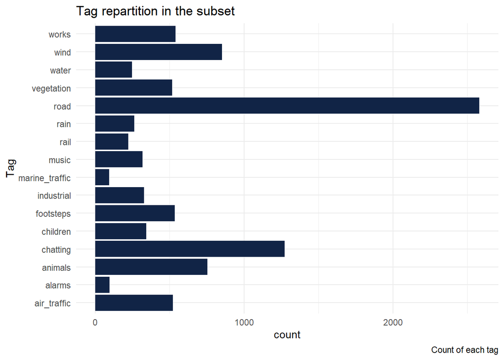

# Time repartition

## All year

```r
all_info <- tag_info %>%
  dplyr::inner_join(
    filtered_track_info %>% sf::st_drop_geometry()) %>%
  # add local hour
  dplyr::mutate(local_time = lubridate::hour( # extract hour
    lubridate::with_tz( # convert to local time
      lubridate::ymd_hms(record_utc, tz = "UTC"), # convert text to date
      "Europe/Paris")), # target timezone
    season = hydroTSM::time2season(lubridate::date(record_utc), out.fmt = "seasons", type="default")) # compute season
all_info %>% head() %>% knitr::kable()
```

| pk_track | tag_name | record_utc | time_length | pleasantness | noise_level | track_uuid | local_time | season |
| --- | --- | --- | --- | --- | --- | --- | --- | --- |
| 1872 | chatting | 2017-12-14 16:20:17 | 62 | NA | 90.54 | f1f6d44c-1399-41fa-8cb9-8becbc43778f | 17 | winter |
| 1872 | children | 2017-12-14 16:20:17 | 62 | NA | 90.54 | f1f6d44c-1399-41fa-8cb9-8becbc43778f | 17 | winter |
| 1872 | footsteps | 2017-12-14 16:20:17 | 62 | NA | 90.54 | f1f6d44c-1399-41fa-8cb9-8becbc43778f | 17 | winter |
| 1872 | music | 2017-12-14 16:20:17 | 62 | NA | 90.54 | f1f6d44c-1399-41fa-8cb9-8becbc43778f | 17 | winter |
| 1872 | road | 2017-12-14 16:20:17 | 62 | NA | 90.54 | f1f6d44c-1399-41fa-8cb9-8becbc43778f | 17 | winter |
| 1872 | rail | 2017-12-14 16:20:17 | 62 | NA | 90.54 | f1f6d44c-1399-41fa-8cb9-8becbc43778f | 17 | winter |

```r
occurences <- all_info %>% dplyr::group_by(tag_name, local_time) %>% dplyr::count(name = "occurences")

occurences %>% head() %>% knitr::kable()
```

| tag_name | local_time | occurences |
| --- | --- | --- |
| air_traffic | 0 | 9 |
| air_traffic | 1 | 1 |
| air_traffic | 3 | 1 |
| air_traffic | 4 | 1 |
| air_traffic | 5 | 1 |
| air_traffic | 8 | 14 |

```r
tags_hourly_repartition <- occurences %>%
  left_join(
    occurences %>% dplyr::group_by(local_time) %>% dplyr::summarise(total = sum(occurences)),
    by = "local_time") %>%
  mutate(percentage = occurences * 100 / total)

tags_hourly_repartition %>% head() %>% knitr::kable()
```

| tag_name | local_time | occurences | total | percentage |
| --- | --- | --- | --- | --- |
| air_traffic | 0 | 9 | 171 | 5.2631579 |
| air_traffic | 1 | 1 | 119 | 0.8403361 |
| air_traffic | 3 | 1 | 50 | 2.0000000 |
| air_traffic | 4 | 1 | 22 | 4.5454545 |
| air_traffic | 5 | 1 | 31 | 3.2258065 |
| air_traffic | 8 | 14 | 116 | 12.0689655 |

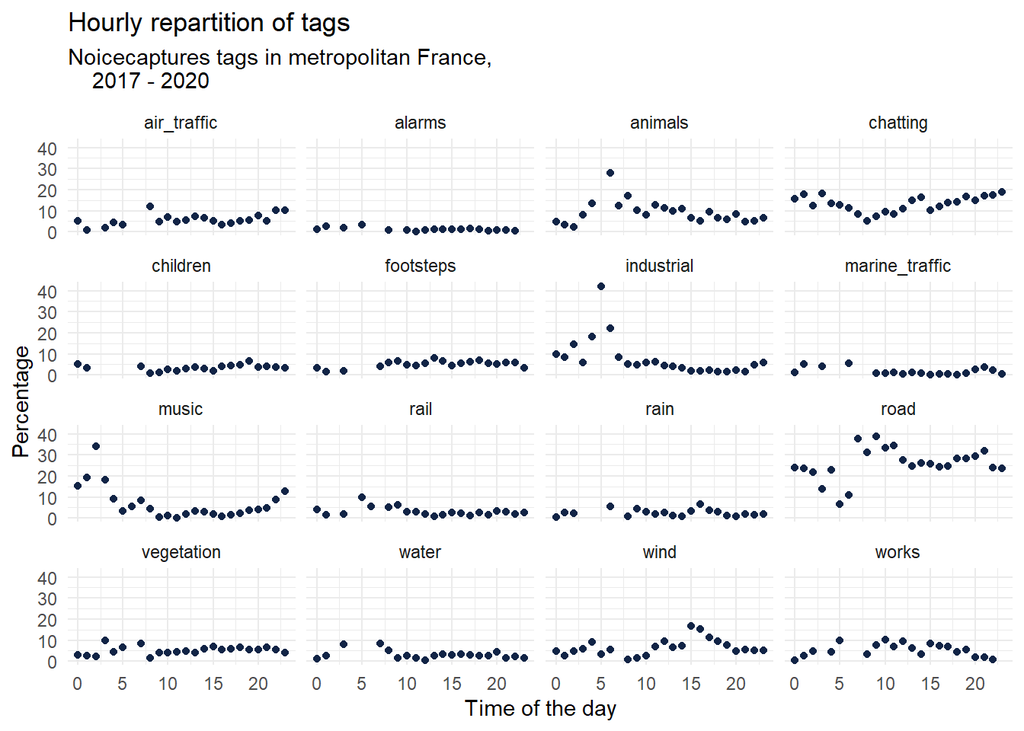

```r
ggplot(tags_hourly_repartition) +
  aes(x = local_time, y = percentage) +
  geom_point(shape = "circle", size = 1.5, colour = "#112446") +
  labs(
    x = "Time of the day",
    y = "Percentage",
    title = "Hourly repartition of tags",
    subtitle = "Noicecaptures tags in metropolitan France,
    2017 - 2020"
  ) +
  theme_minimal() +
  facet_wrap(vars(tag_name))
```

```r
# ggsave("plots/tags_hourly_dynamics.png")
```

## Seasonal repartition

### Animals

```r
seasonal_occurences <- all_info %>%
  dplyr::group_by(tag_name, local_time, season) %>%
  dplyr::count(name = "occurences")

animals_seasonal_repartition <- seasonal_occurences %>%
  dplyr::filter(tag_name == "animals") %>%
  mutate(seasonal_time = paste0(season,'_',local_time)) %>%
  left_join(
    seasonal_occurences %>%
      dplyr::group_by(local_time, season) %>%
      dplyr::summarise(total = sum(occurences))%>%
      dplyr::mutate(seasonal_time = paste0(season,'_',local_time)) %>% select(-season),
    by = "seasonal_time") %>%
  mutate(percentage = occurences * 100 / total)
animals_seasonal_repartition %>% dplyr::select(-local_time.y, -seasonal_time) %>% head() %>% knitr::kable()
```

| tag_name | local_time.x | season | occurences | total | percentage |
| --- | --- | --- | --- | --- | --- |
| animals | 0 | autumm | 3 | 77 | 3.896104 |
| animals | 0 | summer | 5 | 76 | 6.578947 |
| animals | 1 | autumm | 1 | 40 | 2.500000 |
| animals | 1 | summer | 3 | 58 | 5.172414 |
| animals | 2 | autumm | 1 | 13 | 7.692308 |
| animals | 3 | autumm | 2 | 19 | 10.526316 |

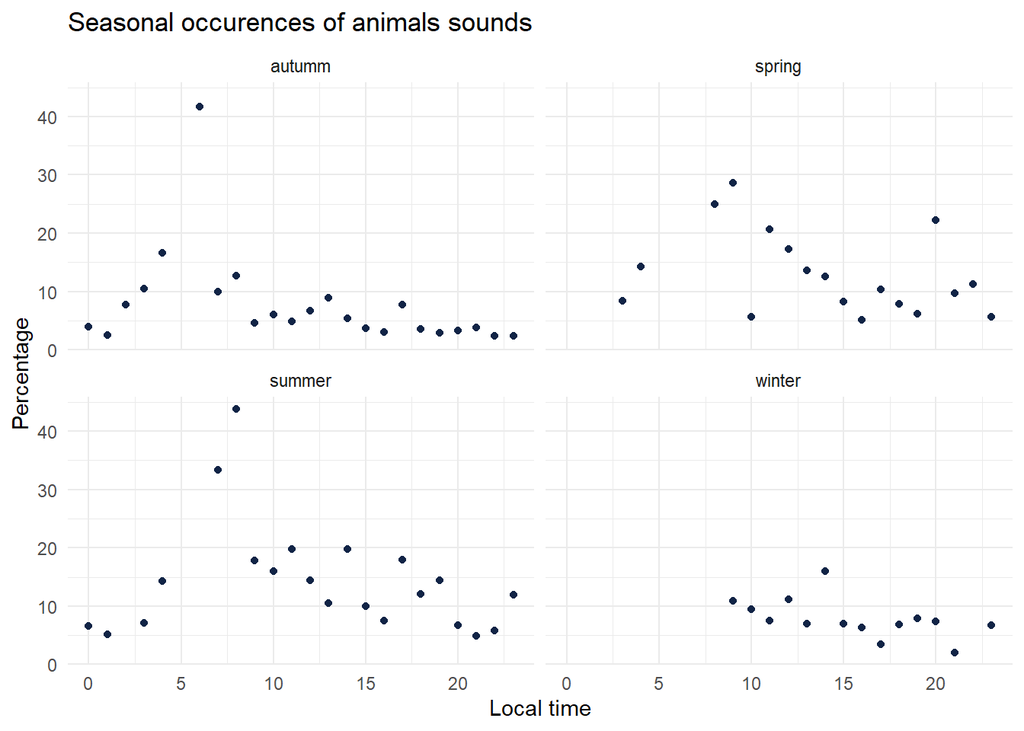

```r
ggplot(animals_seasonal_repartition) +
  aes(x = local_time.x, y = percentage) +
  geom_point(shape = "circle", size = 1.5, colour = "#112446") +
  labs(
    x = "Local time",
    y = "Percentage",
    title = "Seasonal occurences of animals sounds"
  ) +
  theme_minimal() +
  facet_wrap(vars(season))
```

```r
# ggsave("plots/animals_seasonal_dynamic.png")
```

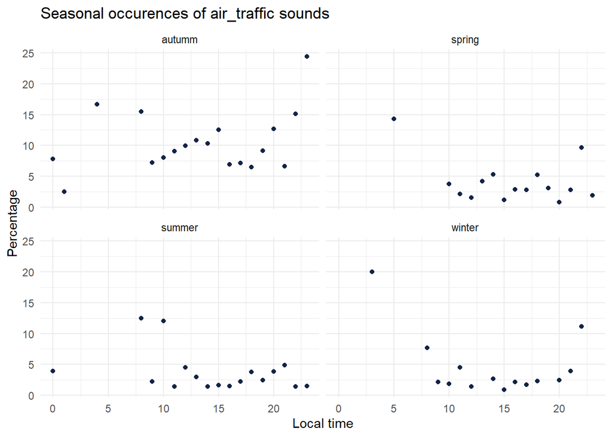

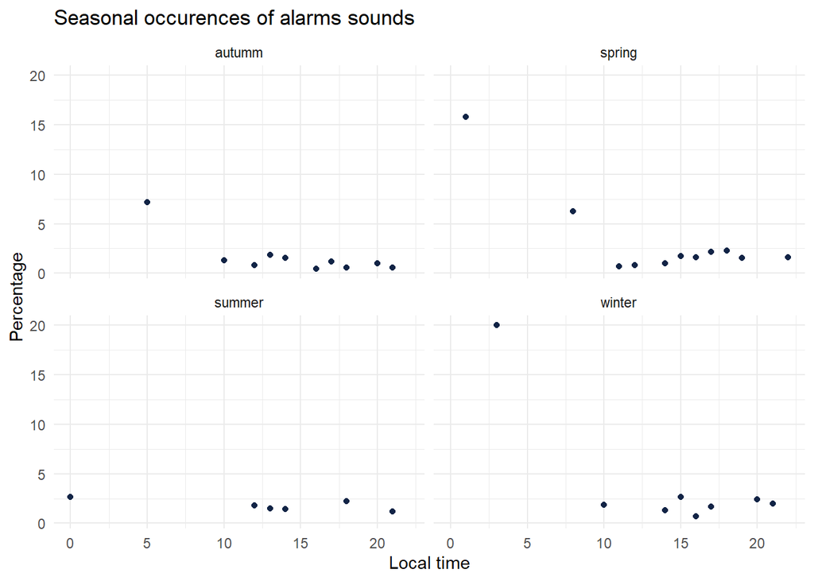

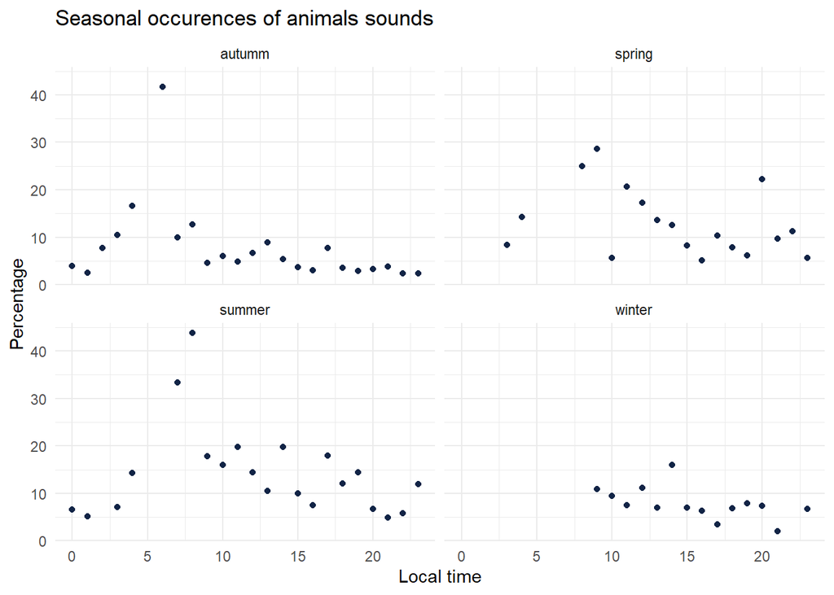

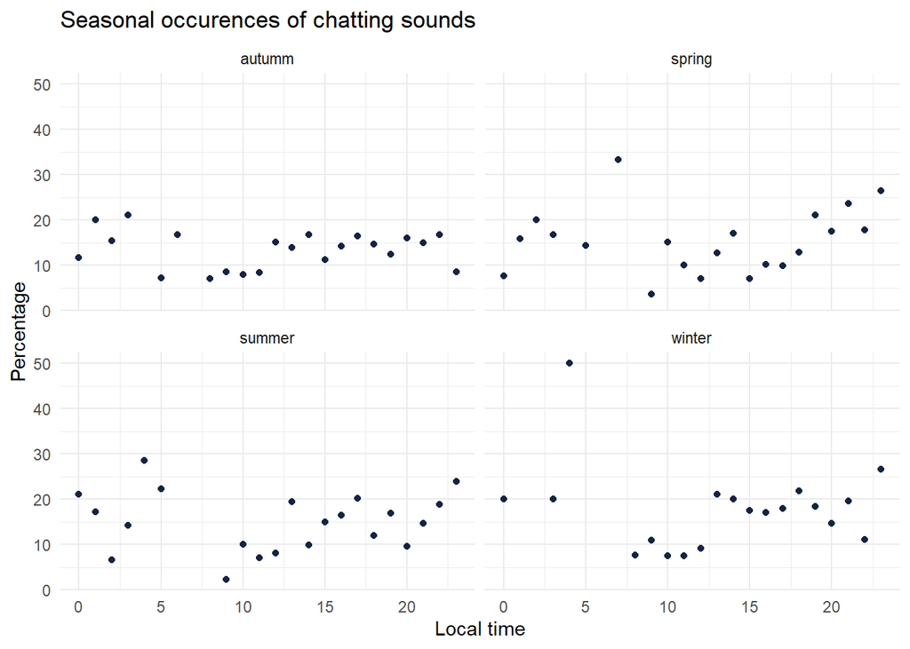

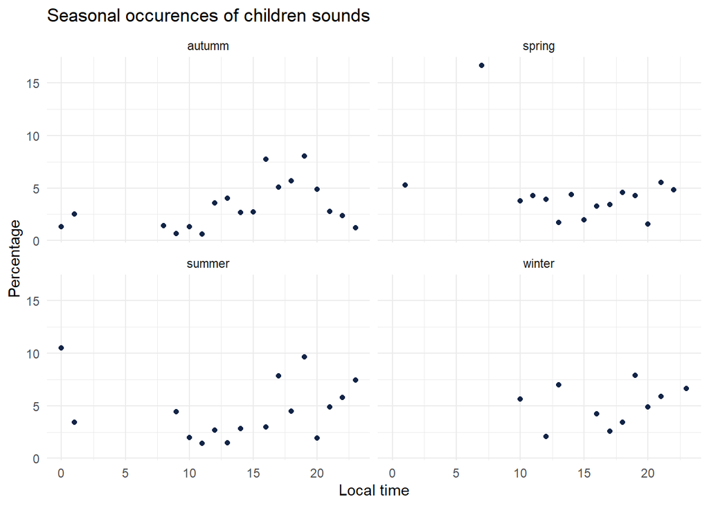

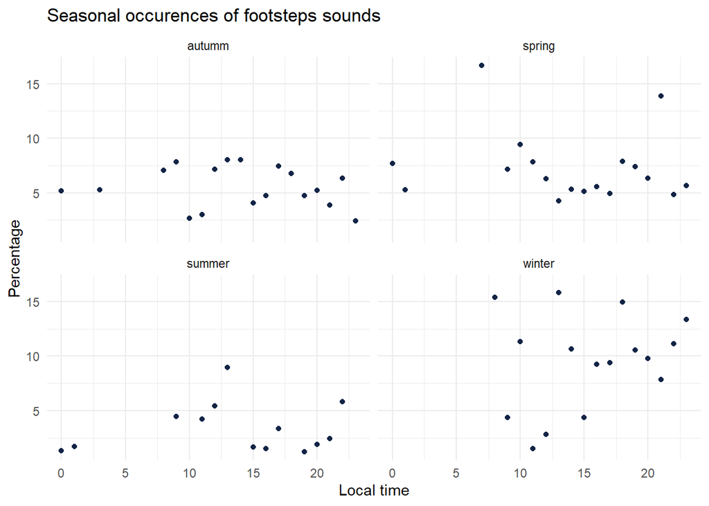

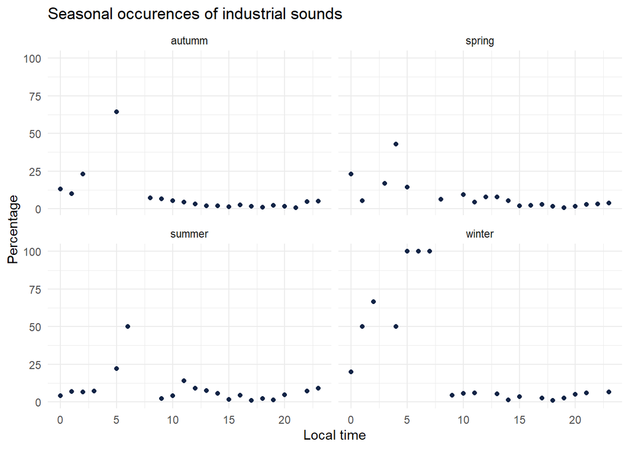

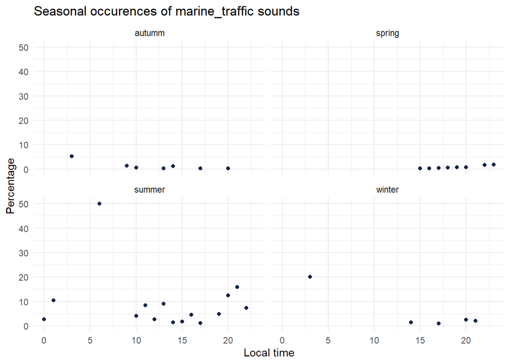

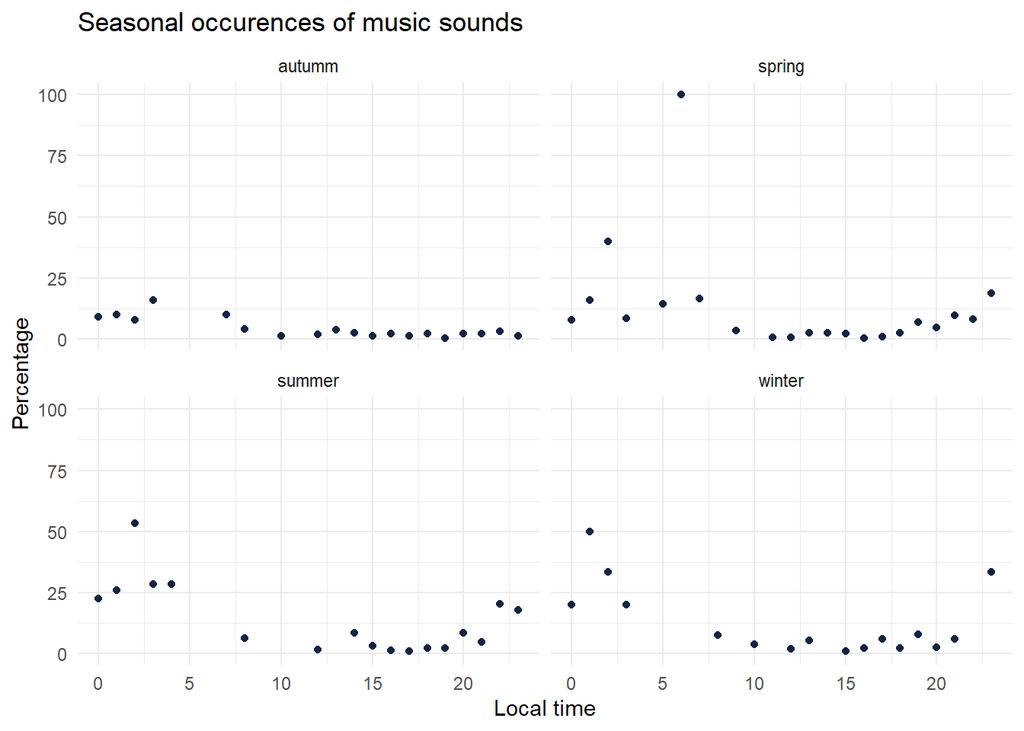

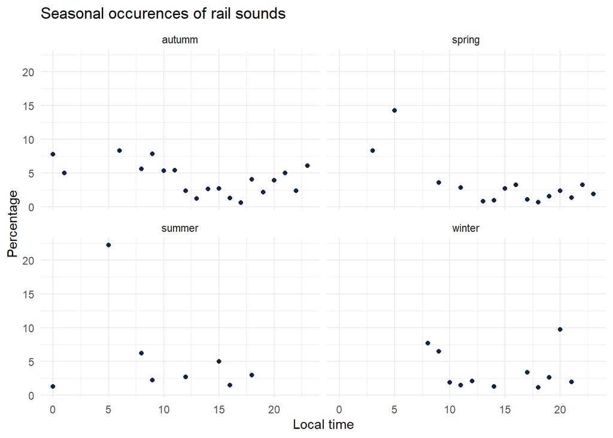

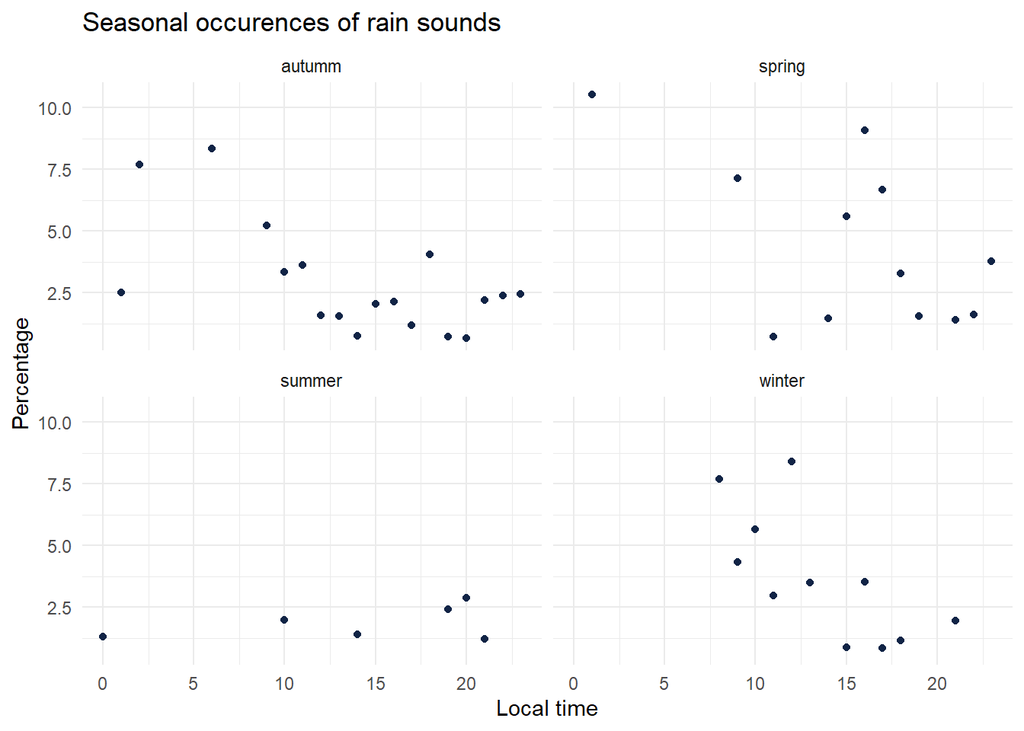

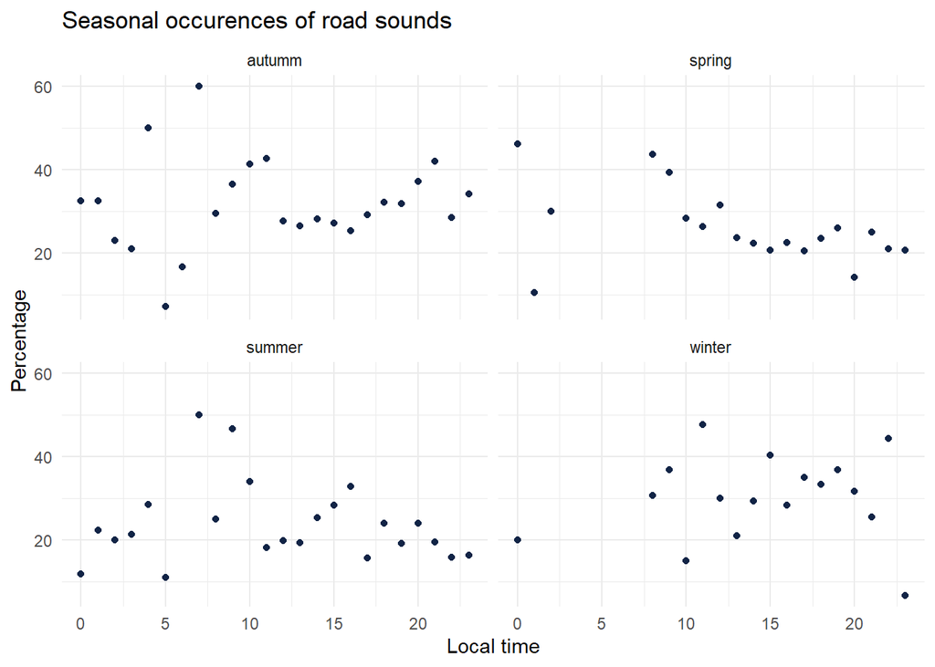

[4 more figures not shown]

```r
season_graphs <- function(tag) {
  seasonal_occurences %>%
  dplyr::filter(tag_name == tag) %>%
  mutate(seasonal_time = paste0(season,'_',local_time)) %>%
  left_join(
    seasonal_occurences %>%
      dplyr::group_by(local_time, season) %>%
      dplyr::summarise(total = sum(occurences))%>%
      dplyr::mutate(seasonal_time = paste0(season,'_',local_time)) %>% select(-season),
    by = "seasonal_time") %>%
  mutate(percentage = occurences * 100 / total) %>%
    ggplot() +
  aes(x = local_time.x, y = percentage) +
  geom_point(shape = "circle", size = 1.5, colour = "#112446") +
  labs(
    x = "Local time",
    y = "Percentage",
    title = paste("Seasonal occurences of",tag,"sounds")
  ) +
  theme_minimal() +
  facet_wrap(vars(season))
}

graphs <- purrr::map(unique(seasonal_occurences$tag_name), season_graphs)
```

# Sound dynamics: sunrise study

```r
get_sunrise <- function(pk_track, date, lat, lon, tz ="UTC") {
  # compute sunrise time from localisation and UTC time
  #return NA if error
  in_pk_track = pk_track
  in_lat = round(lat,5)
  in_lon = round(lon,5)
  in_tz = tz


  sunrise = tryCatch(suncalc::getSunlightTimes(
    date = lubridate::date(date),
    lat = in_lat,
    lon = in_lon,
    tz   = in_tz
  )$sunrise, error=function(e) NA)

  return(dplyr::tribble(
 ~pk_track, ~sunrise,
 in_pk_track, sunrise)
)
}

# Compute track centroid coordinates
suncalc_prep <- filtered_track_info %>% dplyr::bind_cols(
  filtered_track_info %>% st_centroid() %>% st_coordinates() %>% as_tibble() %>% select(lat = Y, lon = X)
)
# Compute sunrise hours for each track in a new dataframe
sunrises <- purrr::pmap_dfr(suncalc_prep %>% select(pk_track, date = record_utc, lat, lon) %>% st_drop_geometry, get_sunrise )
```

```r
# join sunrises to study data
# removes records where sunrise time cannot be compute (track 265404)
time_after_sunrise <- suncalc_prep %>%
  dplyr::inner_join(sunrises %>% filter(!is.na(sunrise))) %>% #remove NAs to avoid errors later on
  dplyr::mutate(local_time = lubridate::hour( # extract hour
    lubridate::with_tz( # convert to local time
      lubridate::ymd_hms(record_utc, tz = "UTC"), # convert text to date
      "Europe/Paris")),
    local_sunrise = lubridate::hour( # extract hour
    lubridate::with_tz( # convert to local time
      lubridate::ymd_hms(sunrise, tz = "UTC"), # convert text to date
      "Europe/Paris")),
    time_after_sunrise = local_time -local_sunrise
    ) %>% left_join( all_info %>% select(pk_track,tag_name))
time_after_sunrise %>% head() %>% knitr::kable()
```

| pk_track | record_utc | time_length | pleasantness | noise_level | track_uuid | lat | lon | sunrise | local_time | local_sunrise | time_after_sunrise | tag_name | geog |
| --- | --- | --- | --- | --- | --- | --- | --- | --- | --- | --- | --- | --- | --- |
| 1872 | 2017-12-14 16:20:17 | 62 | NA | 90.54 | f1f6d44c-1399-41fa-8cb9-8becbc43778f | 47.38944 | 0.6938955 | 2017-12-14 07:38:30 | 17 | 8 | 9 | chatting | POLYGON ((0.6938293 47.3893… |
| 1872 | 2017-12-14 16:20:17 | 62 | NA | 90.54 | f1f6d44c-1399-41fa-8cb9-8becbc43778f | 47.38944 | 0.6938955 | 2017-12-14 07:38:30 | 17 | 8 | 9 | children | POLYGON ((0.6938293 47.3893… |
| 1872 | 2017-12-14 16:20:17 | 62 | NA | 90.54 | f1f6d44c-1399-41fa-8cb9-8becbc43778f | 47.38944 | 0.6938955 | 2017-12-14 07:38:30 | 17 | 8 | 9 | footsteps | POLYGON ((0.6938293 47.3893… |
| 1872 | 2017-12-14 16:20:17 | 62 | NA | 90.54 | f1f6d44c-1399-41fa-8cb9-8becbc43778f | 47.38944 | 0.6938955 | 2017-12-14 07:38:30 | 17 | 8 | 9 | music | POLYGON ((0.6938293 47.3893… |
| 1872 | 2017-12-14 16:20:17 | 62 | NA | 90.54 | f1f6d44c-1399-41fa-8cb9-8becbc43778f | 47.38944 | 0.6938955 | 2017-12-14 07:38:30 | 17 | 8 | 9 | road | POLYGON ((0.6938293 47.3893… |
| 1872 | 2017-12-14 16:20:17 | 62 | NA | 90.54 | f1f6d44c-1399-41fa-8cb9-8becbc43778f | 47.38944 | 0.6938955 | 2017-12-14 07:38:30 | 17 | 8 | 9 | rail | POLYGON ((0.6938293 47.3893… |

```r
occurences <- time_after_sunrise %>% sf::st_drop_geometry() %>% dplyr::group_by(tag_name, time_after_sunrise) %>% dplyr::count(name = "occurences")

time_after_sunrise_repartition <- occurences %>%
  left_join(
    occurences %>% dplyr::group_by(time_after_sunrise) %>% dplyr::summarise(total = sum(occurences)),
    by = "time_after_sunrise") %>%
  mutate(percentage = occurences * 100 / total)

time_after_sunrise_repartition %>% head() %>% knitr::kable()
```

| tag_name | time_after_sunrise | occurences | total | percentage |
| --- | --- | --- | --- | --- |
| air_traffic | -8 | 1 | 27 | 3.703704 |
| air_traffic | -7 | 6 | 88 | 6.818182 |
| air_traffic | -6 | 3 | 88 | 3.409091 |
| air_traffic | -4 | 2 | 66 | 3.030303 |
| air_traffic | -2 | 1 | 38 | 2.631579 |
| air_traffic | 0 | 3 | 43 | 6.976744 |

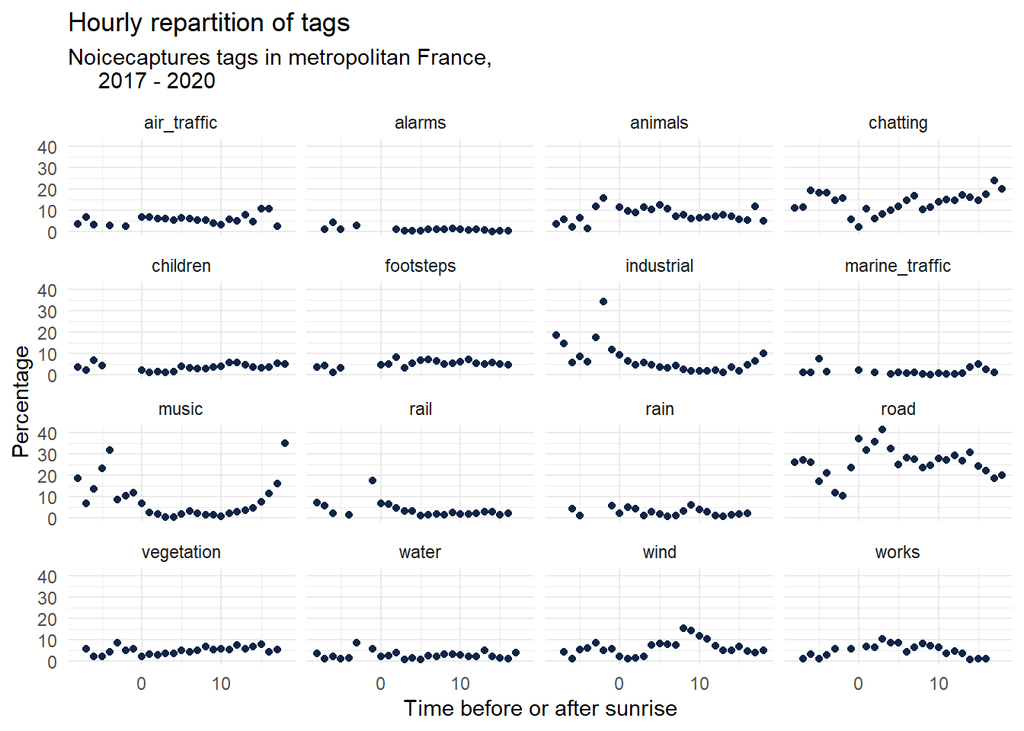

```r
ggplot(time_after_sunrise_repartition) +
   aes(x = time_after_sunrise, y = percentage) +
   geom_point(shape = "circle", size = 1.5, colour = "#112446") +
   labs(
     x = "Time before or after sunrise",
     y = "Percentage",
     title = "Hourly repartition of tags",
     subtitle = "Noicecaptures tags in metropolitan France,
     2017 - 2020"
   ) +
   theme_minimal() +
   facet_wrap(vars(tag_name))
```

```r
# ggsave("plots/tag_dynamics_around_sunrise.png")
```

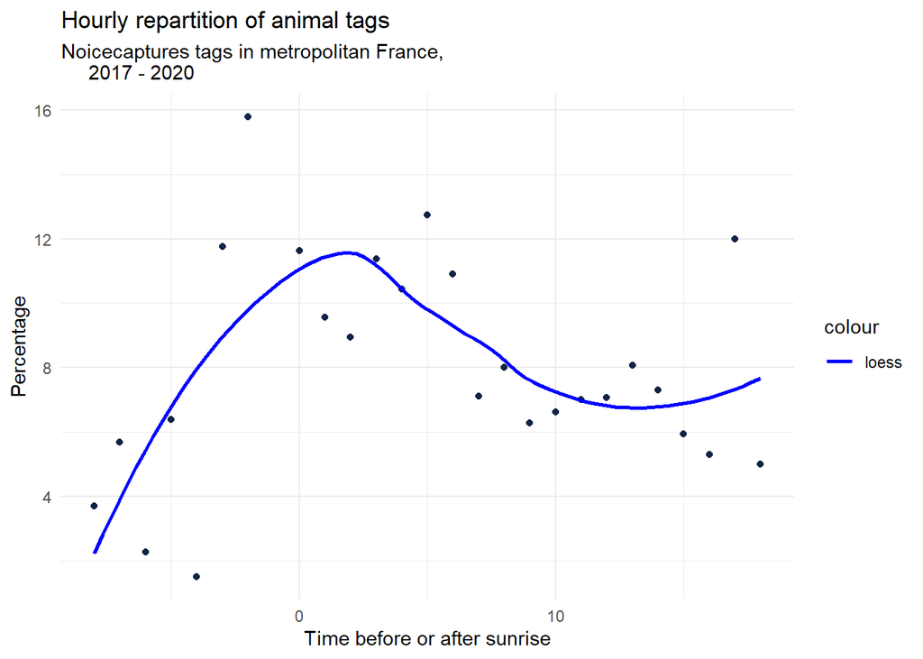

```r
ggplot(time_after_sunrise_repartition %>% dplyr::filter(tag_name == "animals")) +
   aes(x = time_after_sunrise, y = percentage) +
   geom_point(shape = "circle", size = 1.5, colour = "#112446") +
   labs(
     x = "Time before or after sunrise",
     y = "Percentage",
     title = "Hourly repartition of animal tags",
     subtitle = "Noicecaptures tags in metropolitan France,
     2017 - 2020"
   ) +
   geom_smooth(method = "loess", se = FALSE, aes(colour="loess")) + # smooth curve test (see span parameter to fit more to the peak before sunrise)
  # geom_smooth(method = "lm", formula = y ~ poly(x, 3), se = FALSE, aes(colour="Polynomial")) +
  scale_colour_manual(values=c("blue", "red"))+
   theme_minimal()
```

```r
# ggsave("plots/animal_dynamics_around_sunrise.png")
```

# Monthly repartition

```r
monthly_occurences <- all_info %>% dplyr::mutate(local_month = lubridate::month( # extract hour
    lubridate::with_tz( # convert to local time
      lubridate::ymd_hms(record_utc, tz = "UTC"), # convert text to date
      "Europe/Paris"))) %>%
  dplyr::group_by(tag_name, local_month, season) %>%
  dplyr::count(name = "occurences")

tags_monthly_repartition <- monthly_occurences %>%  left_join(
    monthly_occurences %>% dplyr::group_by(local_month) %>% dplyr::summarise(total = sum(occurences)),
    by = "local_month") %>%
  mutate(percentage = occurences * 100 / total)
```

```r
data_breaks <- data.frame(start = c(0, 3, 6, 9),  # Create data with breaks
                          end = c(3, 6, 9, 12),
                          Seasons = factor(c("Winter", "Spring", "Summer", "Autumn"),
                                          levels = c("Winter", "Spring", "Summer", "Autumn"),
                          labels = c("Winter", "Spring", "Summer", "Autumn")))
data_breaks                                       # Print data with breaks
```

```
##   start end Seasons
## 1     0   3  Winter
## 2     3   6  Spring
## 3     6   9  Summer
## 4     9  12  Autumn
```

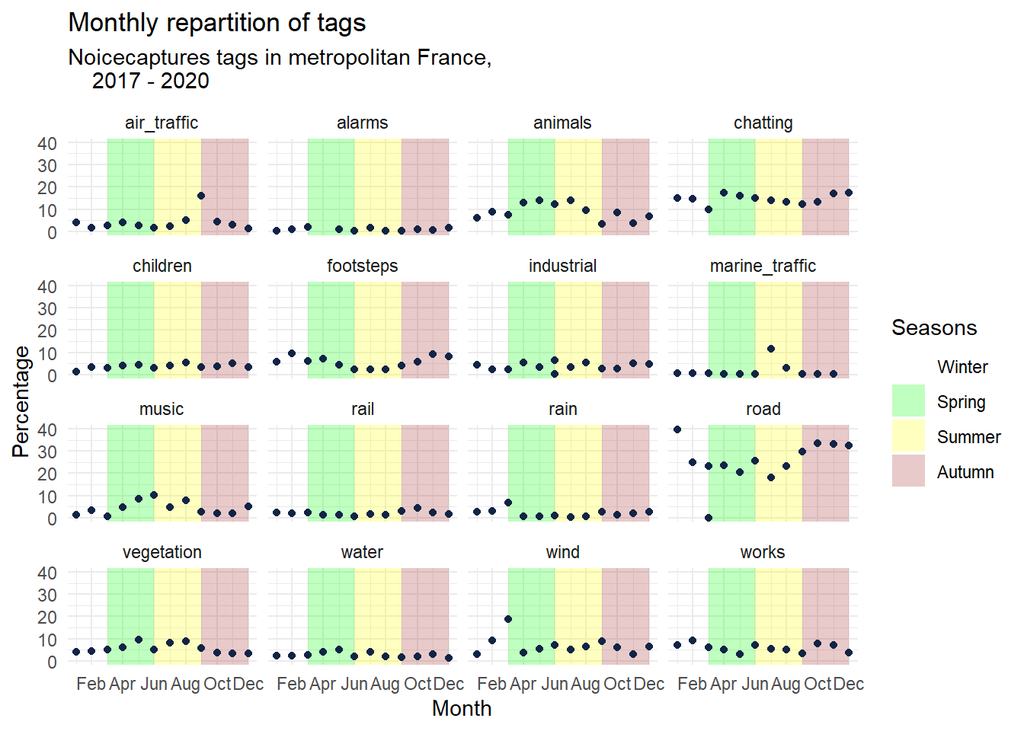

```r
ggplot() +
  # Add background colors to plot
  geom_rect(data = data_breaks,
            aes(xmin = start,
                xmax = end,
                ymin = - Inf,
                ymax = Inf,
                fill = Seasons),
            alpha = 0.25) +
  scale_fill_manual(values = c("Winter" = "white",
                               "Spring" = "green",
                               "Summer" = "yellow",
                               "Autumn" = "brown"
                               )) +
  geom_point(data = tags_monthly_repartition, aes(x = local_month, y = percentage),
             shape = "circle", size = 1.5, colour = "#112446") +
  labs(
    x = "Month",
    y = "Percentage",
    title = "Monthly repartition of tags",
    subtitle = "Noicecaptures tags in metropolitan France,
    2017 - 2020"
  ) +
  theme_minimal() +
  scale_x_continuous(breaks = scales::pretty_breaks(), labels=c("Jan","Feb","Apr","Jun", "Aug", "Oct", "Dec", "null"), limits = c(1,12))+
  facet_wrap(vars(tag_name))
```

```r
# ggsave("plots/tags_monthly_dynamics.png")
```

# TODO

- timezones : https://github.com/Ifsttar/NoiseCapture/tree/master/onomap-geoserver/geoserver/src/test/resources/org/noise_planet/noisecapturegs
  - loaded in database
  - not used because metropolitan France study only
  - intersect track geom with timezones and use timezone variable in computations (“Europe/Paris” -> tz)
- investiguate with there is doubles in tags_monthly_dynamic graph in Road March and industrial June (data related ? Agregation ?)

# Packages citations

```r
citation("tidyverse")
```

```
##
##   Wickham et al., (2019). Welcome to the tidyverse. Journal of Open
##   Source Software, 4(43), 1686, https://doi.org/10.21105/joss.01686
##
## Une entrée BibTeX pour les utilisateurs LaTeX est
##
##   @Article{,
##     title = {Welcome to the {tidyverse}},
##     author = {Hadley Wickham and Mara Averick and Jennifer Bryan and Winston Chang and Lucy D'Agostino McGowan and Romain François and Garrett Grolemund and Alex Hayes and Lionel Henry and Jim Hester and Max Kuhn and Thomas Lin Pedersen and Evan Miller and Stephan Milton Bache and Kirill Müller a…
##     year = {2019},
##     journal = {Journal of Open Source Software},
##     volume = {4},
##     number = {43},
##     pages = {1686},
##     doi = {10.21105/joss.01686},
##   }
```

```r
citation("sf")
```

```
##
##
##   Pebesma, E., 2018. Simple Features for R: Standardized Support for
##   Spatial Vector Data. The R Journal 10 (1), 439-446,
##   https://doi.org/10.32614/RJ-2018-009
##
## Une entrée BibTeX pour les utilisateurs LaTeX est
##
##   @Article{,
##     author = {Edzer Pebesma},
##     title = {{Simple Features for R: Standardized Support for Spatial Vector Data}},
##     year = {2018},
##     journal = {{The R Journal}},
##     doi = {10.32614/RJ-2018-009},
##     url = {https://doi.org/10.32614/RJ-2018-009},
##     pages = {439--446},
##     volume = {10},
##     number = {1},
##   }
```

```r
citation("hydroTSM")
```

```
##
##
##   Mauricio Zambrano-Bigiarini. (2020) hydroTSM: Time Series Management,
##   Analysis and Interpolation for Hydrological ModellingR package
##   version 0.6-0. URL https://github.com/hzambran/hydroTSM.
##   DOI:10.5281/zenodo.839864.
##
## Une entrée BibTeX pour les utilisateurs LaTeX est
##
##   @Manual{,
##     title = {hydroTSM: Time Series Management, Analysis and Interpolation for Hydrological Modelling},
##     author = {{Mauricio Zambrano-Bigiarini}},
##     year = {2020},
##     note = {R package version 0.6-0 . doi: https://doi.org/10.5281/zenodo.83964},
##     url = {https://github.com/hzambran/hydroTSM},
##   }
##
## I have invested an important amount of time and effort in creating
## hydroTSM, please cite it if you use it !
```

```r
citation("suncalc")
```

```
##
##
##   Benoit Thieurmel and Achraf Elmarhraoui (2019). suncalc: Compute Sun
##   Position, Sunlight Phases, Moon Position and Lunar Phase. R package
##   version 0.5.0. https://CRAN.R-project.org/package=suncalc
##
## Une entrée BibTeX pour les utilisateurs LaTeX est
##
##   @Manual{,
##     title = {suncalc: Compute Sun Position, Sunlight Phases, Moon Position and Lunar
## Phase},
##     author = {Benoit Thieurmel and Achraf Elmarhraoui},
##     year = {2019},
##     note = {R package version 0.5.0},
##     url = {https://CRAN.R-project.org/package=suncalc},
##   }
```

# Reproductibility

## Data sources

Most of the treatment has been made within the PostGIS database. The scripts folder contains several scripts to execute to prepare the dataset.

## Database information

```r
# Check database connection and software versions
RPostgreSQL::dbGetQuery(con,statement = paste("SELECT version();")) # should return PostgreSQL 10.15 or higher
```

```
##                                                                                                                             version
## 1 PostgreSQL 10.19 (Ubuntu 10.19-1.pgdg18.04+1) on x86_64-pc-linux-gnu, compiled by gcc (Ubuntu 7.5.0-3ubuntu1~18.04) 7.5.0, 64-bit
```

```r
RPostgreSQL::dbGetQuery(con,statement = paste("SELECT postgis_full_version();")) # should return PostGIS 2.5 or higher
```

```
##                                                                                                                                                                                            postgis_full_version
## 1 POSTGIS="2.5.5" [EXTENSION] PGSQL="100" GEOS="3.7.1-CAPI-1.11.1 27a5e771" PROJ="Rel. 4.9.3, 15 August 2016" GDAL="GDAL 2.4.2, released 2019/06/28" LIBXML="2.9.4" LIBJSON="0.12.1" LIBPROTOBUF="1.2.1" RASTER
```

```
## [1] TRUE
```